# 05_read_counts

Natalia Andrade Rodriguez

2023-03-16

#Mergin read count per sample obtained with STAR

##Loading/installing libraries

```r
library(data.table)
library(ggplot2)
library(ggrepel)
library(dplyr)
library(tidyr)
library(reshape2)
library(tidyverse)
```

#Sorting samples with less than 4M and 5M reads mapped

```r
reads_mapped<- read.delim("data/STAR_multiqc_general_stats.txt", sep = "\t")
head(reads_mapped)
```

```
##      Sample STAR_mqc.generalstats.star.uniquely_mapped_percent
## 1 103_LC064                                              20.92
## 2 103_LC114                                              30.20
## 3 103_MC026                                              19.39
## 4 103_MC027                                              31.87
## 5 108_LC007                                              28.37
## 6 108_LC062                                              13.49
##   STAR_mqc.generalstats.star.uniquely_mapped
## 1                                    1251058
## 2                                    1080605
## 3                                    1108634
## 4                                    1603693
## 5                                    1046808
## 6                                    1135128
```

```r
reads_mapped<- reads_mapped %>%

               rename(percent_uniq = STAR_mqc.generalstats.star.uniquely_mapped_percent) %>%

               rename(million_uniq = STAR_mqc.generalstats.star.uniquely_mapped) %>%

               rename(Sample_ID = Sample)

samples_selected_4M<- reads_mapped %>% filter(million_uniq > 4000000)

samples_selected_5M<- reads_mapped %>% filter(million_uniq > 5000000)
```

```r
sample_metadata<- read.csv("data/meta_NOVA_lab.csv")

names(sample_metadata)
```

```
##  [1] "X"                                  "AssessID"
##  [3] "Species"                            "P1_label"
##  [5] "Location"                           "Region"
##  [7] "depth_ft_colony_base"               "firstvisit_date"
##  [9] "length"                             "width"
## [11] "height"                             "Surface_Area"
## [13] "total_periods_visited"              "total_periods_diseased"
## [15] "treat_type"                         "total_treatments"
## [17] "Resistance_April2021"               "Resistance2_April2021"
## [19] "X.visits_diseased_total"            "X.visits_diseased_May21.Mar22"
## [21] "X.LiveTissueDifference_total"       "X.LiveTissueDifference_Apr21.Mar22"
## [23] "Zoox_dominant"                      "Zoox_background"
## [25] "date"                               "time"
## [27] "process_time"                       "disease"
## [29] "coresite_angle"                     "core_location"
## [31] "core_heading"                       "core_depth"
## [33] "ID"                                 "Falcon_Tube"
## [35] "Sample_Period"                      "Sample_ID"
## [37] "Sample_name"                        "RNA_Original_concentration"
## [39] "RNA_Dilution_concentration"         "Cq"
## [41] "Plate_Number"
```

```r
sample_metadata_reads<- sample_metadata %>% left_join(samples_selected_4M, by="Sample_ID")
```

```r
samples_selected_4M<- sample_metadata_reads %>%

                      filter(!is.na(million_uniq))  %>%

                      filter(Species != 'Ofra') %>%

                      mutate(SP1 = case_when(Sample_Period == '1' ~ TRUE)) %>%

                      mutate(SP2 = case_when(Sample_Period == '2' ~ TRUE)) %>%

                      mutate(SP3 = case_when(Sample_Period == '3' ~ TRUE)) %>%

                      mutate(uniqsample = 1)

samples_selected_4M$Sample_Period<- as.character(samples_selected_4M$Sample_Period)
samples_selected_4M$RNA_Dilution_concentration<- as.character(samples_selected_4M$RNA_Dilution_concentration)


n_colonies_4M<- unique(samples_selected_4M$ID) #79

#write.csv(samples_selected_4M, "data/samples_selected_4M.csv")
```

#Creating variables based on colony ID and sample period SP1_SP2: samples of colonies from which we have data from sample period 1 and 2 (but not sample period 3) SP1_SP3: samples of colonies from which we have data from sample period 1 and 3 (but not sample period 2) SP2_SP3: samples of colonies from which we have data from sample period 2 and 3 (but not sample period 1) SP1_SP2_SP3: samples of colonines from which we have data from the 3 samples periods

```r
function_sample_period<- readRDS('function_sample_period.rds')
sample_period_data_cast<- function_sample_period(samples_selected_4M)
sample_period_data <- melt(sample_period_data_cast,

                  id=c("Resistance_April2021", "ID", 'SP1_SP2','SP1_SP3','SP2_SP3', 'SP1_SP2_SP3'),

                  variable_name = "Sample_ID") %>%

                  filter(!is.na(value)) %>%

                  rename(Sample_ID = variable) %>%

                  dplyr::select(- Resistance_April2021, - ID, -value)
```

#Select colonies from which we have samples for the different sample periods

```r
#Data set with samples of colonies from which we have data for samples period 1, 2 and 3

all_sp<- sample_period_data %>%

         filter(SP1_SP2_SP3 == 1) %>%

         select(Sample_ID, SP1_SP2_SP3)

sp1_sp2_sp3<- all_sp %>%                                          #27 samples / 9 colonies

              left_join(samples_selected_4M, by ="Sample_ID")

n_colonies_sp_all<- unique(sp1_sp2_sp3$ID)
```

```r
#Data set with samples of colonies from which we have data for samples period 1 and 2

sp1_sp2<- sample_period_data %>%                                 #22 samples / 11 colonies

          filter(SP1_SP2 == 1) %>%

          select(Sample_ID, SP1_SP2 ) %>%

          bind_rows(all_sp) %>%

          left_join(samples_selected_4M, by ="Sample_ID") %>%

          filter(Sample_Period != '3')

n_colonies_sp1_2<- unique(sp1_sp2$ID)
```

```r
#Data set with samples of colonies from which we have data for samples period 1 and 3

sp1_sp3<- sample_period_data %>%                                #22 samples / 11 colonies

          filter(SP1_SP3 == 1) %>%

          select(Sample_ID, SP1_SP3 ) %>%

          bind_rows(all_sp) %>%

          left_join(samples_selected_4M, by ="Sample_ID") %>%

          filter(Sample_Period != '2')

n_colonies_sp1_3<- unique(sp1_sp3$ID)
```

```r
#Data set with samples of colonies from which we have data for samples period 2 and 3

sp2_sp3<- sample_period_data %>%                             #104 samples / 52 unique colonies

          filter(SP2_SP3 == 1) %>%

          select(Sample_ID, SP2_SP3 ) %>%

          bind_rows(all_sp) %>%

          left_join(samples_selected_4M, by ="Sample_ID") %>%

          filter(Sample_Period != '1')

n_colonies_sp2_3<- unique(sp2_sp3$ID)

#write.csv(sp2_sp3, "data/sp2_sp3.csv")
```

#List will be use to select files for the countData_4M and countData_sp2_3

```r
#for the countData_4M
for_list_samples_4M<- samples_selected_4M  %>% select(Sample_ID)
#write_delim(for_list_samples_4M, 'hpc/data/sample_list_4M.txt')

#for the countData_sp2_3

for_list_sp2_sp3<- sp2_sp3 %>% select(Sample_ID)

#write_delim(for_list_sp2_sp3, 'hpc/data/sample_list_sp2_3.txt')
```

#Creating a list of all files from samples that have atleast 4M reads mapped

```r
dir<- "/Volumes/LaCie_NAR/Cnidarian_Immunity_lab/NOVA_SCTLD/data/star_trimmed_reads/"
```

```r
file_4M<- list.files(paste0(dir,"samples_4M_reads" ),
                  "*.gzReadsPerGene.out.tab$", full.names = T)
```

```r
countData_4M = data.frame(fread(file_4M[1]))[c(1,3)]

for(i in 2:length(file_4M)) {
        countData_4M = cbind(countData_4M, data.frame(fread(file_4M[i]))[3])
}
```

```r
# Skip first 4 lines, count data starts on the 5th line
countData_4M = countData_4M[c(5:nrow(countData_4M)),]
colnames(countData_4M) = c("GeneID", gsub(paste0(dir,"samples_4M_reads/"), "", file_4M))
colnames(countData_4M) = gsub("_trimmed.fq.gzReadsPerGene.out.tab", "", colnames(countData_4M))
rownames(countData_4M) = countData_4M$GeneID

countData_4M = countData_4M[,c(2:ncol(countData_4M))]

#write_rds(countData_4M, "data/countData_4M.rds")
```

#Creating a list of all files of samples from the same colonies at samples period 2 and 3

```r
file_sp2_3<- list.files(paste0(dir,"samples_sp2_3_reads" ),
                  "*.gzReadsPerGene.out.tab$", full.names = T)
```

```r
countData_sp2_3 = data.frame(fread(file_sp2_3[1]))[c(1,3)]

for(i in 2:length(file_sp2_3)) {
        countData_sp2_3 = cbind(countData_sp2_3, data.frame(fread(file_sp2_3[i]))[3])
}
```

```r
# Skip first 4 lines, count data starts on the 5th line
countData_sp2_3 = countData_sp2_3[c(5:nrow(countData_sp2_3)),]
colnames(countData_sp2_3) = c("GeneID", gsub(paste0(dir,"samples_sp2_3_reads/"), "", file_sp2_3))
colnames(countData_sp2_3) = gsub("_trimmed.fq.gzReadsPerGene.out.tab", "", colnames(countData_sp2_3))
rownames(countData_sp2_3) = countData_sp2_3$GeneID

countData_sp2_3 = countData_sp2_3[,c(2:ncol(countData_sp2_3))]

#write_rds(countData_sp2_3, "data/countData_sp2_3.rds")
```

#Plotting read counts

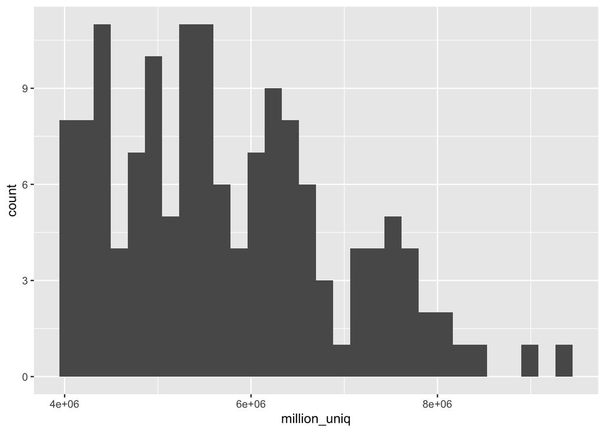

```r
ggplot(samples_selected_4M, aes(million_uniq)) + geom_histogram()
```

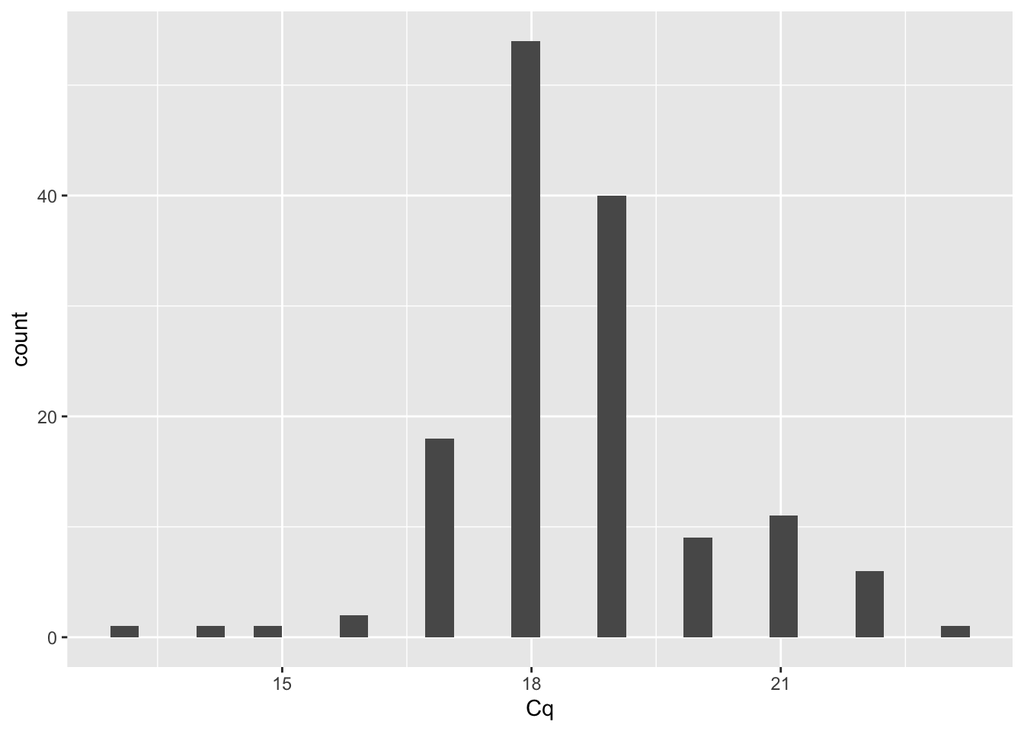

```r
ggplot(samples_selected_4M, aes(Cq)) + geom_histogram()
```

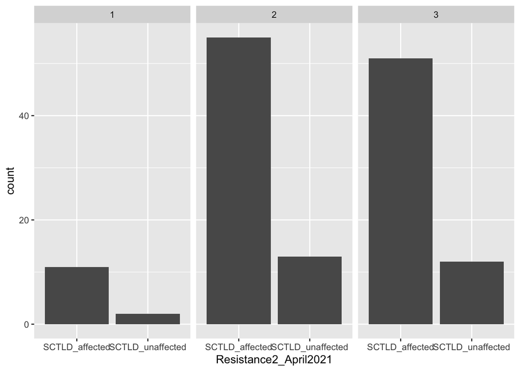

```r
ggplot(samples_selected_4M, aes(Resistance2_April2021)) + geom_bar() + facet_grid(  ~ Sample_Period)
```

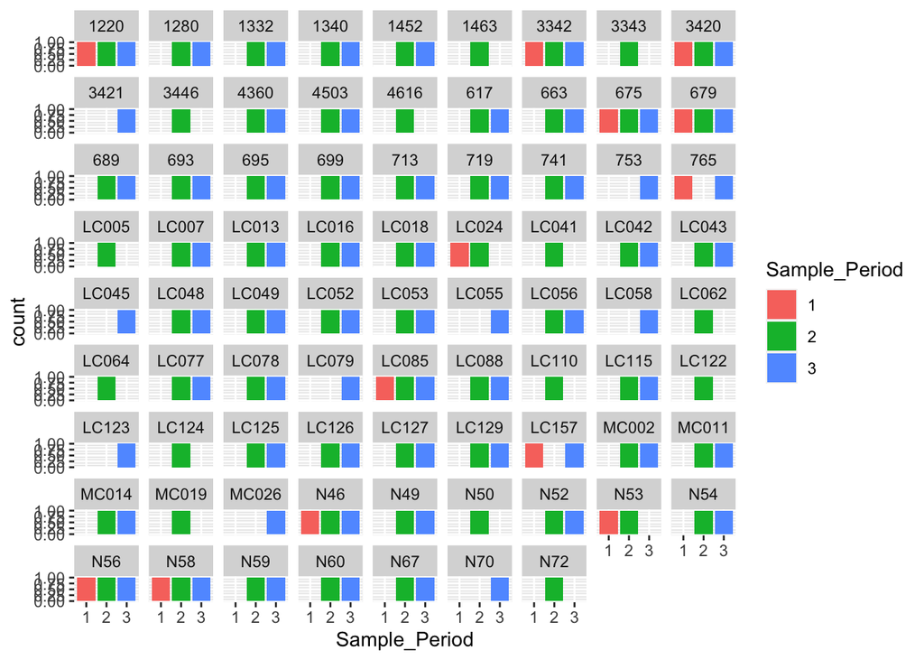

```r
ggplot(samples_selected_4M, aes(Sample_Period)) + geom_bar(aes(fill=Sample_Period), position = "dodge") + facet_wrap(~ ID )
```

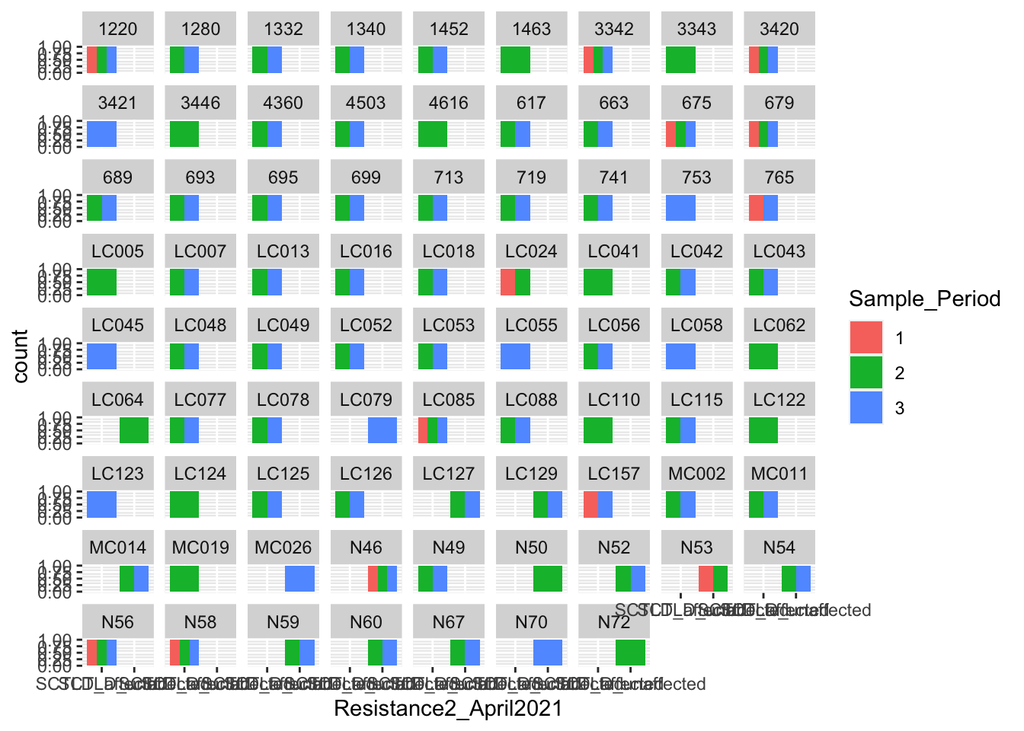

```r
ggplot(samples_selected_4M, aes(Resistance2_April2021)) + geom_bar(aes(fill=Sample_Period), position = "dodge") + facet_wrap(~ ID )
```

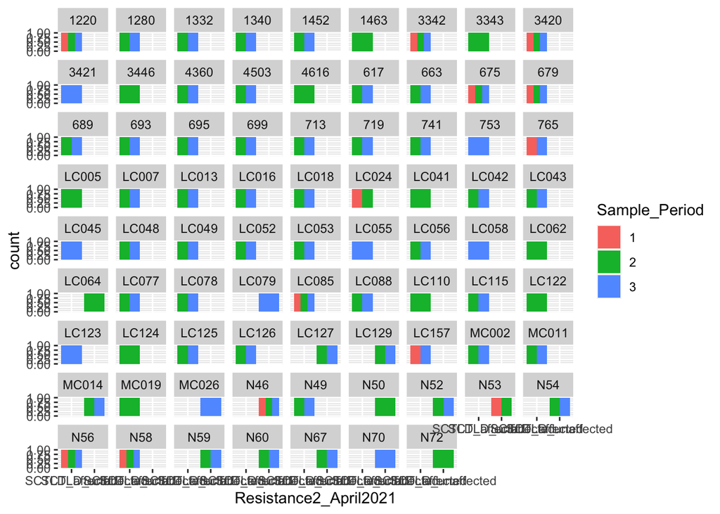

```r
forplot<- samples_selected_4M %>% group_by(Sample_Period, Resistance2_April2021)

ggplot(samples_selected_4M, aes(Resistance2_April2021)) + geom_bar(aes(fill=Sample_Period), position = "dodge") + facet_wrap(~ ID )
```

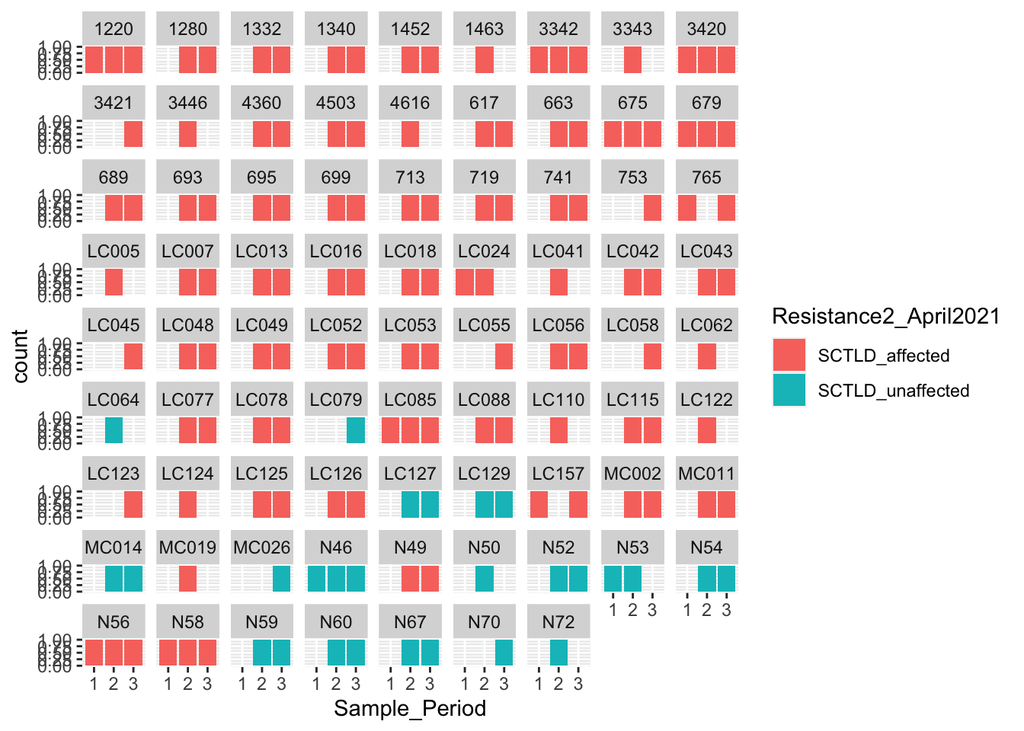

```r
ggplot(samples_selected_4M, aes(Sample_Period)) + geom_bar(aes(fill=Resistance2_April2021), position = "dodge") + facet_wrap(ID ~ . )
```

#Visualising samples that can be analysed together based on sample periode

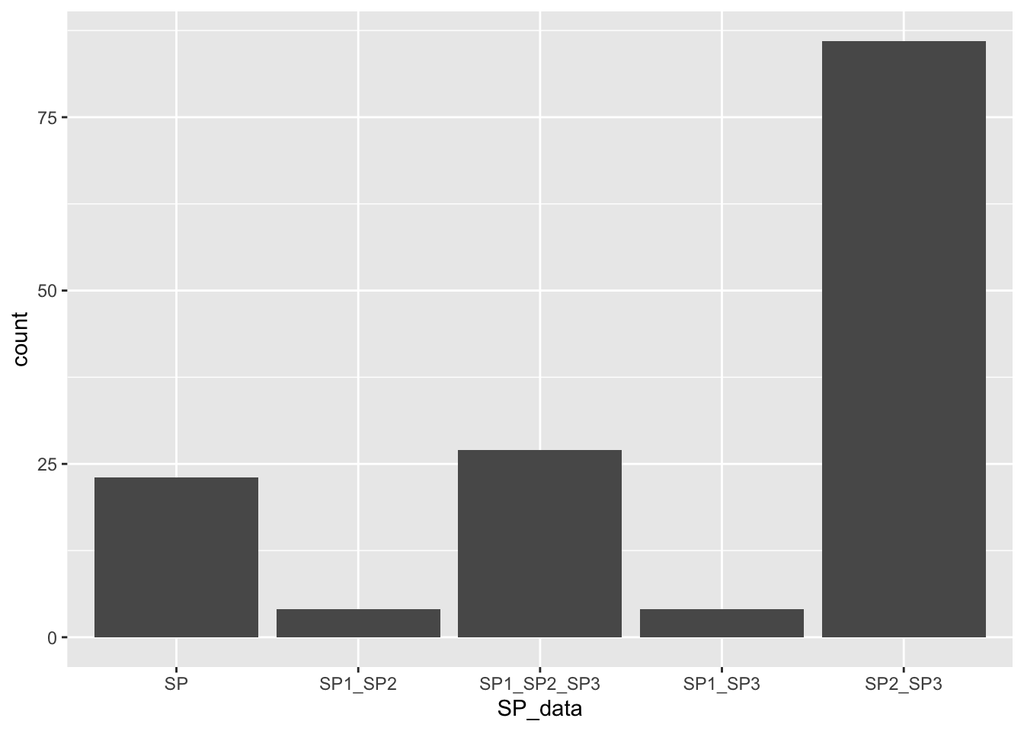

```r
sample_period_plot<- sample_period_data %>% mutate(SP_data = case_when(

                                            SP1_SP2 == 1 ~ 'SP1_SP2' ,
                                            SP1_SP3 == 1 ~ 'SP1_SP3' ,
                                            SP2_SP3 == 1 ~ "SP2_SP3" ,
                                            SP1_SP2_SP3 == 1 ~ "SP1_SP2_SP3",
                                            is.na(SP1_SP2) ~"SP"))

sample_period_plot_cast<- sample_period_data_cast %>% mutate(SP_data = case_when(

                                            SP1_SP2 == 1 ~ 'SP1_SP2' ,
                                            SP1_SP3 == 1 ~ 'SP1_SP3' ,
                                            SP2_SP3 == 1 ~ "SP2_SP3" ,
                                            SP1_SP2_SP3 == 1 ~ "SP1_SP2_SP3",
                                            is.na(SP1_SP2) ~"SP"))


ggplot(sample_period_plot, aes(SP_data)) +

      geom_bar()
```

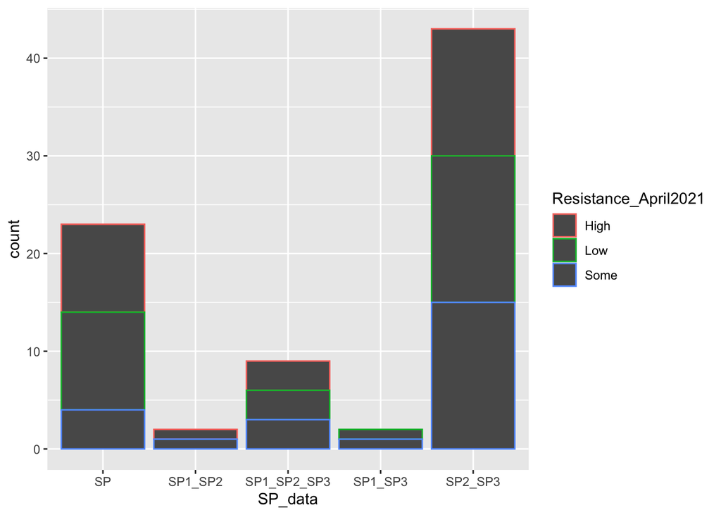

```r
ggplot(sample_period_plot_cast, aes(SP_data)) +

      geom_bar(aes(color=Resistance_April2021))
```

```r
 #    + geom_text(aes(label = after_stat()), vjust = 0)
```